# Visualizing geographic predictions of genetic offset measures

Olivier François

### Introduction

Genomic offset statistics predict the maladaptation of populations to rapid habitat alteration based on association of genotypes with environmental variation. This brief tutorial explains how to represent predictions of genomic offset statistics within geographic maps. This can be achieved using standard `R` packages dedicated to spatial analysis.

In the tutorial, spatial prediction of genomic offset will be illustrated by analyzing publicly available genomic data from 1,096 European lines of the model plant *Arabidopsis thaliana* (https://www.1001genomes.org/) and climate models described in the sixth IPCC report (IPCC AR6).

To represent geographic maps, there are many other and often better methods than the ones presented in the tutorial. I do not claim being a cartography specialist and the approach below is likely suboptimal. It is at least quite flexible, easy to reproduce, and can be used as basis for improved representations.

### Loading genomic and environmental data

Displaying genomic offset statistics in geographic space will require that the `R` packages `terra`, `geodata`, `fields`, and `maps` are installed. The tutorial will use `LEA` for performing a genotype-environment association study and for computing genomic offset statistics.

```r
# Required packages
# Loading worldclim/cimp6 bioclimatic data
library(terra)
```

```r
library(geodata)

# displaying images and maps
library(fields)
library(maps)

# Adjusting genotype-environment association models
library(LEA)
```

Genomic and geographic data for A. thaliana samples are available from a previous tutorial on **running structure-like population genetic analyses with `R`**. The data contain 1,096 genotypes from the first chromosome of the plant and geographic coordinates (latitude and longitude) associated with each sample. They can be downloaded as follows.

```r
# default timeout option is 60s -- increase to 300s
options(timeout = max(300, getOption("timeout")))

# download sample genotypes in the working directory (54.4 MB)
url = "http://membres-timc.imag.fr/Olivier.Francois/Arabidopsis/A_thaliana_chr1.geno"
download.file(url = url, destfile = "./A_thaliana_chr1.geno")

# download sample coordinates in the working directory
url = "http://membres-timc.imag.fr/Olivier.Francois/Arabidopsis/at_coord.coord"
download.file(url = url, destfile = "./at_coord.coord")
```

The data are then loaded as `R` objects, and the sample coordinates can be visualized as follows.

```r
genotype = LEA::read.geno("./A_thaliana_chr1.geno")
coordinates = as.matrix(read.table("./at_coord.coord"))
```

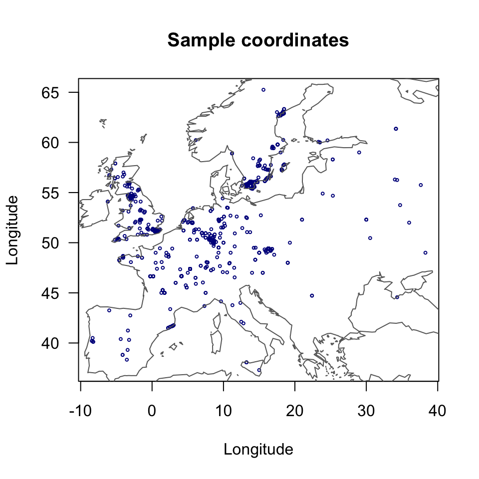

```r
plot(coordinates, cex = .4, col = "darkblue",
     xlab = "Longitude", ylab = "Longitude",
     main = "Sample coordinates", las = 1)

maps::map(add = TRUE, interior = FALSE, col = "grey40")
```

### Bioclimatic variables

In the following presentation, predictions will be based on bioclimatic variables from the worldclim database. The bioclimatic variables are downloaded below. The `climate` object contains 19 historical temperature and precipitation variables with low resolution. A temporary path is used for downloading. If additional analyses are planed, changing to non-temporary folders could be useful to avoid reloading (which may be slow).

```r
# Download global bioclimatic data from worldclim
climate <- geodata::worldclim_global(var = 'bio',
                                     res = 10,
                                     download = TRUE,
                                     path=tempdir())
```

Next, the `climate_future` object contains future temperature and precipitation variables predicted from the SSP2-4.5 scenario developed with respect to the sixth IPCC report (IPCC AR6). There are several prediction models, and the one used here is called ‘ACCESS-ESM1-5’.

```r
# Download future climate scenario from 'ACCESS-ESM1-5' climate model.
climate_future <- geodata::cmip6_world(model='ACCESS-ESM1-5',
                                       ssp='245',
                                       time='2041-2060',
                                       var='bioc',
                                       download = TRUE,
                                       res=10,
                                       path=tempdir())
```

Now, environmental data can be extracted for each sample site. The extraction command results in an environmental matrix `X.env` having 1,096 rows and 19 columns after removing IDs.

```r
# extracting historical environmental data for A. thaliana samples
X.env = terra::extract(x = climate,
                       y = data.frame(coordinates),
                       cells = FALSE)
# remove IDs
X.env = X.env[,-1]

# extracting future environmental data for A. thaliana samples
#X.env_fut = terra::extract(x = climate_future, y = data.frame(coordinates), cells=FALSE)
#X.env_fut = X.env_fut[,-1]
```

### Genotype-Environment Association study

To evaluate genomic offset statistics, environmental effect sizes must be estimated at each genomic locus. This can be achieved by applying a latent factor model in `LEA`. Based on a previous analysis, five latent factors are used. Because temperature and precipitation have distinct units, the environmental data will be scaled to unit standard deviation. In other words, the data will be centered by substracting their mean, and then divided by their standard deviation.

Another approach reduces the dimension of the bioclimatic data set by performing separate scaled PCA on temperature and precipitation variables. New variables could then be defined by retaining the first components in each separate analysis. This is not implemented here because our sample size is large.

```r
# latent factor GEA model
mod_lfmm = LEA::lfmm2(input = genotype,
                      env = scale(X.env),
                      K = 5,
                      effect.sizes = TRUE)

# get environmental effect sizes
B <- mod_lfmm@B
```

The GEA model can also be used to define a subset of candidate loci to be included in genomic offset computation.

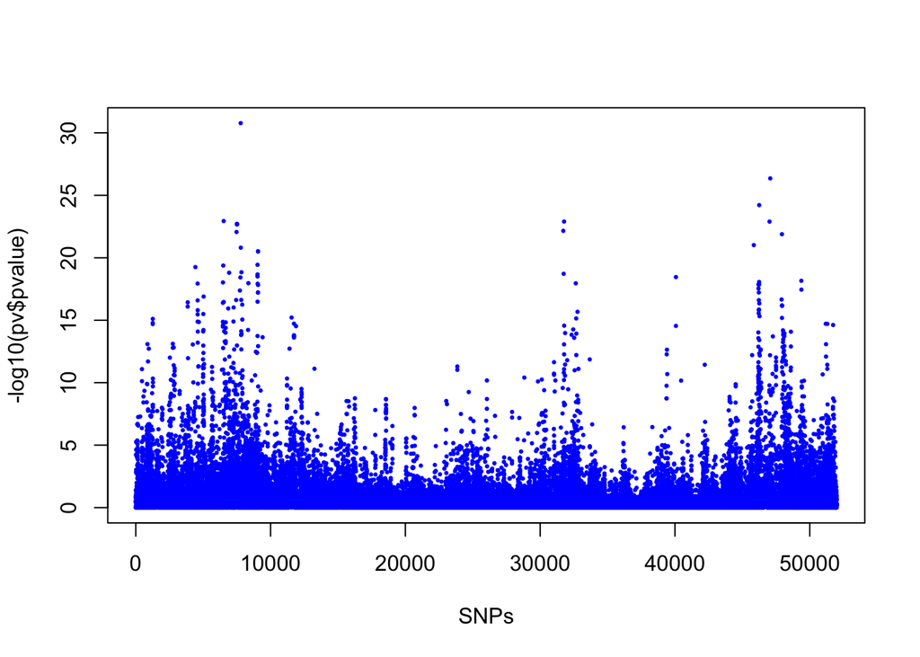

```r
pv = lfmm2.test(mod_lfmm, input = genotype, env = scale(X.env), full = TRUE)
plot(-log10(pv$pvalue),
     xlab = "SNPs",
     cex = .3, pch = 19, col = "blue")
```

A set of candidate loci needs to be relatively large. Statistical significance is not a requirement here, and a cut-off threshold at 5 can be chosen (but try 0 to 4).

```r
# define candidate loci for GO analysis
candidates =  -log10(pv$pvalue) > 5

# taking all loci for GO analysis
# candidates =  -log10(pv$pvalue) > 0

# how many candidate loci?
sum(candidates)
```

```
## [1] 1328
```

### Extracting historical and future climate for Europe

First, a reasonable range of longitude and latitude coordinates must be defined. This range of values includes the European mainland and some islands. Below `nc` is a critical resolution parameter. Increasing its value produces more precise maps at higher costs.

```r
## nc = resolution, higher is better but slower
nc = 200

# range of longitude for Europe (deg E)
long.mat <- seq(-10, 40, length = nc)

# range of latitude for Europe (deg N)
lat.mat <- seq(36, 67, length = nc)

# matrix of cells for Europe (nc times nc)
coord.mat <- NULL
for (x in long.mat)
  for (y in lat.mat) coord.mat <- rbind(coord.mat, c(x,y))
```

Then, the `R` package `terra` can extract the climate and the future climate data for every cell defined in the above coordinate matrix.

```r
# Extract historical climate
env.new = terra::extract(x = climate,
                         y = data.frame(coord.mat),
                         cells = FALSE)
env.new = env.new[,-1]

# Extract future climate
env.pred = terra::extract(x = climate_future,
                          y = data.frame(coord.mat),
                          cells=FALSE)
env.pred = env.pred[,-1]
```